# Reproducible Research: Peer Assessment 1

## Loading and preprocessing the data

Before analyzing the data, we need to load the data into R. The assignment instructions inform us that the input data contains three columns: `steps`, `date`, and `interval`. Furthermore the instructions indicate that the dataset is stored in a comma-separated-value (CSV) file and that there are a total of 17,568 observations in it. The input data is in the file `activity.zip`. From the extension, we will assume that it is in compressed format.

Just to make sure that our assumption is correct and to get a sense of the input data, we will take a quick peek at a few records from the input file. For this task we could use external programs like `head` or `tail`. However, while these are usually available on *nix systems, they are not available on standard Windows systems (unless added on later by Cygwin or msys etc.).

To remain platform-agnostic, instead of using `read.csv()` from the base R system we will use the `fread()` function from the `data.table` package. Also, the data loading code assumes that open source 7-Zip archive management software is available in the in the search path of the OS.

```r
# Set the working directory and get the contents of the .zip file
setwd("~/Coursera/Data Science Specialization/5. Reproducible Research/RepData_PeerAssessment1")
cat(paste(system("7za l activity.zip", intern = TRUE), "\n"))
```

```
##
##  7-Zip (a) [64] 9.38 beta  Copyright (c) 1999-2014 Igor Pavlov  2015-01-03
##
##  Listing archive: activity.zip
##
##  --
##  Path = activity.zip
##  Type = zip
##  Physical Size = 53559
##
##     Date      Time    Attr         Size   Compressed  Name
##  ------------------- ----- ------------ ------------  ------------------------
##  2014-02-11 11:08:20 .....       350829        53385  activity.csv
##  ------------------- ----- ------------ ------------  ------------------------
##  2014-02-11 11:08:20             350829        53385  1 files
##
##  Kernel  Time =     0.015 =   86%
##  User    Time =     0.000 =    0%
##  Process Time =     0.015 =   86%    Virtual  Memory =      3 MB
##  Global  Time =     0.018 =  100%    Physical Memory =      5 MB
```

```r
# Load the data.table package
library(data.table)

# Read the data into a data.table with default fread() options
dt = fread("7za e -so activity.zip activity.csv 2>nul")

# Take a look at the data
str(dt)
```

```
## Classes 'data.table' and 'data.frame':   17568 obs. of  3 variables:
##  $ steps   : int  NA NA NA NA NA NA NA NA NA NA ...
##  $ date    : chr  "2012-10-01" "2012-10-01" "2012-10-01" "2012-10-01" ...
##  $ interval: int  0 5 10 15 20 25 30 35 40 45 ...
##  - attr(*, ".internal.selfref")=<externalptr>
```

```r
dt
```

```
##        steps       date interval
##     1:    NA 2012-10-01        0
##     2:    NA 2012-10-01        5
##     3:    NA 2012-10-01       10
##     4:    NA 2012-10-01       15
##     5:    NA 2012-10-01       20
##    ---
## 17564:    NA 2012-11-30     2335
## 17565:    NA 2012-11-30     2340
## 17566:    NA 2012-11-30     2345
## 17567:    NA 2012-11-30     2350
## 17568:    NA 2012-11-30     2355
```

The instructions indicate that the variable `interval` is the identifier for 5-minute intervals. The first intervals start with the series [0, 5, 10, …], and if it were a continuous series during the day, we would expect the following:

```r
# Number of intervals in a day
intervals_per_hour = 60/5
intervals_per_day = 24 * intervals_per_hour

# Sequence of intervals for one day
data.table(seq(from = 0, by = 5, length.out = intervals_per_day))
```

```
##        V1
##   1:    0
##   2:    5
##   3:   10
##   4:   15
##   5:   20
##  ---
## 284: 1415
## 285: 1420
## 286: 1425
## 287: 1430
## 288: 1435
```

The tail end of the source dataset doesn’t match this vector. In fact, it looks more like the time of the day in 24-hour format, but without the “:” separator. To confirm this, we can take a quick look at the end of the hour and the end of the day:

```r
# Check out the end of the first hour
dt[(intervals_per_hour - 1):(intervals_per_hour + 2)]
```

```
##    steps       date interval
## 1:    NA 2012-10-01       50
## 2:    NA 2012-10-01       55
## 3:    NA 2012-10-01      100
## 4:    NA 2012-10-01      105
```

```r
# Check out the 24-hour boundary between the first and second day
dt[(intervals_per_day - 1):(intervals_per_day + 2)]
```

```
##    steps       date interval
## 1:    NA 2012-10-01     2350
## 2:    NA 2012-10-01     2355
## 3:     0 2012-10-02        0
## 4:     0 2012-10-02        5
```

It looks like the `interval` column is actually the time of the day, but it is formatted as a number: e.g. `55` is followed by `100`; `2355` is followed by `0`, etc. In case we need a properly formatted `interval` and a proper date and time variable in later steps, we will transform them and keep them in a new Date/Time column.

```r
# Load lubridate package for easy handling of dates/times
library(lubridate)

# Reformat date and time and convert to date/time class
dt[, interval  := sub("^(..)", "\\1:", sprintf("%04d", interval))]
dt[, timestamp := ymd_hm(paste(date, interval))]
dt[, date      := ymd(date)]
str(dt)
```

```
## Classes 'data.table' and 'data.frame':   17568 obs. of  4 variables:
##  $ steps    : int  NA NA NA NA NA NA NA NA NA NA ...
##  $ date     : POSIXct, format: "2012-10-01" "2012-10-01" ...
##  $ interval : chr  "00:00" "00:05" "00:10" "00:15" ...
##  $ timestamp: POSIXct, format: "2012-10-01 00:00:00" "2012-10-01 00:05:00" ...
##  - attr(*, ".internal.selfref")=<externalptr>
```

## What is mean total number of steps taken per day?

To summarize data by group, we can use the `aggregate()` function from the base R system, or utilize the modern interfaces provided in `data.table` or `dplyr` packages. For this assignment, we will use `data.table` interface.

This section will try to analyze the distribution of the total number of steps taken per day throughout the study period using a histogram, then provide the mean and the median of this metric as formal descriptors of its distribution.

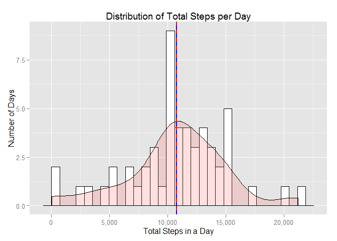

```r
# Get the steps by date, but don't remove NAs: this will make sure that if all
# the intervals in a day have NAs, the day's total steps will also be NA.
# If we remove them, the sum for the day will be zero and the daily average of
# the total steps will be incorrectly underestimated.
steps_by_date = dt[, .( total_steps = sum(steps) ), date]

# Load the ggplot2 library
library(ggplot2)

# For comma formatted axis labels
require(scales)

# Create a function to plot the data with ggplot
plot_it = function(dt_to_plot, scale, plot_title) {
  ggplot(dt_to_plot, aes(x = total_steps)) +
    geom_histogram     ( colour = "black", fill = "white"                     ) +
    ggtitle            ( plot_title                                           ) +
    xlab               ( "Total Steps in a Day"                               ) +
    ylab               ( "Number of Days"                                     ) +
    scale_x_continuous ( labels = comma                                       ) +
    geom_density       ( aes_string(y = scale), alpha = 0.2, fill = "#FF6666" ) +
    geom_vline         ( aes(xintercept = mean(total_steps, na.rm = TRUE)),
                         color = "red", size = 1                              ) +
    geom_vline         ( aes(xintercept = median(total_steps, na.rm = TRUE)),
                         color = "blue", linetype = "dashed", size = 1        )
}

plot_it(steps_by_date, "..scaled..*4.35", "Distribution of Total Steps per Day")
```

```r
# Get the mean and median: now we have to use na.rm to remove days with NAs
stats = steps_by_date[,
  .(
    mean   = mean   ( total_steps, na.rm = TRUE ),
    median = median ( total_steps, na.rm = TRUE )
  )
]

stats
```

```
##        mean median
## 1: 10766.19  10765
```

During the study period, after removing the missing data, the mean steps taken per day was **10,766.19**, shown as a red vertical line on the plot. The median steps taken per day was **10,765**, shown with blue vertical dashes.

### A note about the `na.rm` option in `sum()`

In the instructions for the above analysis, there is a specific comment about “ignoring the missing values in the dataset”. This could mean “removing” them from the analysis as in `sum(..., na.rm = TRUE)`, or it could mean doing nothing about them, i.e. use `sum(...)` which is the same as `sum(..., na.rm = FALSE)`. In the distribution example above, we used the `sum()` function twice, and only in one of them we used the option `na.rm = TRUE`. This was an important feature of the analysis, because doing it differently would yield a very different result. In this section, we will repeat the analysis using the alternative approach and illustrate how it is different from the correct approach.

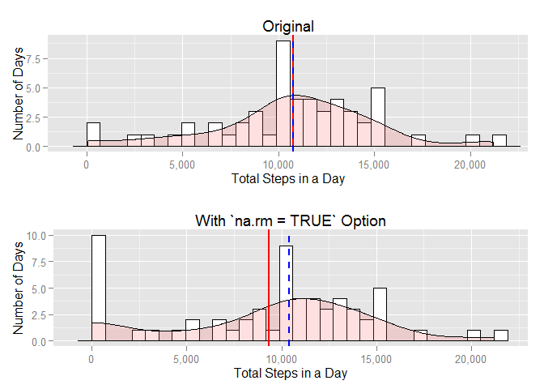

```r
# Since we are not using facets, manually force the same x-axis scale
plot_it2 = function(dt_to_plot, scale, plot_title) {
  ggplot(dt_to_plot, aes(x = total_steps)) +
    geom_histogram     ( colour = "black", fill = "white"                     ) +
    ggtitle            ( plot_title                                           ) +
    xlab               ( "Total Steps in a Day"                               ) +
    ylab               ( "Number of Days"                                     ) +
    scale_x_continuous ( labels = comma                                       ) +
    geom_density       ( aes_string(y = scale), alpha = 0.2, fill = "#FF6666" ) +
    geom_vline         ( aes(xintercept = mean(total_steps, na.rm = TRUE)),
                         color = "red", size = 1                              ) +
    geom_vline         ( aes(xintercept = median(total_steps, na.rm = TRUE)),
                         color = "blue", linetype = "dashed", size = 1        ) +
    coord_cartesian    ( xlim = c(-2000, 23000)                               )
}

# Original approach
plot1 = plot_it2(steps_by_date, "..scaled..*4.35", "Original")

# Alternative approach
steps_by_date_alt = dt[, .( total_steps = sum(steps, na.rm = TRUE) ), date]
plot2 = plot_it2(steps_by_date_alt, "..scaled..*4", "With `na.rm = TRUE` Option")

# Stack the two plots
require(grid)
grid.newpage()
pushViewport(viewport(layout = grid.layout(nrow = 2, ncol = 1)))
print(plot1, vp = viewport(layout.pos.row = 1, layout.pos.col = 1))
print(plot2, vp = viewport(layout.pos.row = 2, layout.pos.col = 1))
```

```r
# Summary stats for the original approach
summary(steps_by_date)
```

```
##       date             total_steps
##  Min.   :2012-10-01   Min.   :   41
##  1st Qu.:2012-10-16   1st Qu.: 8841
##  Median :2012-10-31   Median :10765
##  Mean   :2012-10-31   Mean   :10766
##  3rd Qu.:2012-11-15   3rd Qu.:13294
##  Max.   :2012-11-30   Max.   :21194
##                       NA's   :8
```

```r
# Summary stats for the alternative approach
summary(steps_by_date_alt)
```

```
##       date             total_steps
##  Min.   :2012-10-01   Min.   :    0
##  1st Qu.:2012-10-16   1st Qu.: 6778
##  Median :2012-10-31   Median :10395
##  Mean   :2012-10-31   Mean   : 9354
##  3rd Qu.:2012-11-15   3rd Qu.:12811
##  Max.   :2012-11-30   Max.   :21194
```

The results show that, using the `na.rm = TRUE` option introduces eight days with total step count of zero, which moves the mean (red vertical line) and the median (blue vertical dashes) towards the left.

## What is the average daily activity pattern?

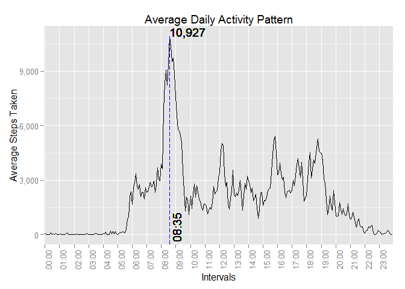

```r
# Average of steps taken by interval over the study period
steps_by_interval = dt[, .(average_steps = sum(steps, na.rm = TRUE)), interval]

# Info on the interval with the max average steps
max_step_index     = steps_by_interval[, which.max(average_steps)]
max_steps          = steps_by_interval[max_step_index, average_steps]
max_steps_interval = steps_by_interval[max_step_index, interval]

# There are too many intervals to be plotted: pick the top of the hour to label
# the tick marks
labels = steps_by_interval[seq(1, length(interval), 12), interval]

# Line graph of average activity during the day
activity = ggplot(steps_by_interval, aes(x = interval, y = average_steps, group = 1)) +
  geom_line          ( ) +
  ggtitle            ( "Average Daily Activity Pattern") +
  xlab               ( "Intervals") +
  ylab               ( "Average Steps Taken") +
  scale_x_discrete   ( breaks = labels, labels = as.character(labels)) +
  scale_y_continuous ( labels = comma) +
  theme              ( axis.text.x = element_text(angle = 90))

# Now, add the info about the max steps to the plot and show it
activity +
  geom_segment(
    linetype = "longdash",
    colour   = "blue",
    aes(x = max_step_index, y = -Inf, xend = max_step_index, yend = max_steps)
  ) +
  geom_text(
    x     = max_step_index,
    y     = max_steps,
    label = prettyNum(max_steps, big.mark = ","),
    hjust = 0,
    vjust = 0
  ) +
  geom_text(
    x     = max_step_index,
    y     = 0,
    label = max_steps_interval,
    hjust = 0.25,
    vjust = 1.25,
    angle = 90
  )
```

## Imputing missing values

There are a number of cases where there are no observations for an interval or an entire day (coded as NA). The presence of missing data may introduce bias into some calculations or summaries of the data. The following code chunk shows the number of intervals with missing data.

```r
# Intervals with missing values
nrow(na.omit(dt, invert = TRUE))
```

```
## [1] 2304
```

Note that having some intervals with missing data may have different implications than having entire days without data, especially if more of some specific days had missing data. The following section provides some comparisons.

```r
# Days without data
missing_days = dt[,
  .(
    nmiss = nrow(na.omit(.SD, invert = TRUE)),
    dow   = wday(date, label = TRUE, abbr = TRUE)
  ),
  date
][nmiss > 0]

missing_days
```

```
##          date nmiss   dow
## 1: 2012-10-01   288   Mon
## 2: 2012-10-08   288   Mon
## 3: 2012-11-01   288 Thurs
## 4: 2012-11-04   288   Sun
## 5: 2012-11-09   288   Fri
## 6: 2012-11-10   288   Sat
## 7: 2012-11-14   288   Wed
## 8: 2012-11-30   288   Fri
```

```r
# Percentage of days with missing data
nrow(missing_days)/uniqueN(dt[, date])*100
```

```
## [1] 13.11475
```

It looks like whenever there is a missing observation, an entire day’s worth of data are missing. From the above summary, there doesn’t appear to be a pattern to the days with missing data. One approach to imputing data for these missing intervals is to assign the average number of steps taken across the entire span of the study period.

An alternative approach is to get the average of the interval for specific days of the week: it is likely that a person’s daily activity on a weekend day will be more similar to another weekend day rather than a week day. We can extend the same logic and assume that the expected activity pattern on a Monday will be similar to the average of activities across all Mondays; and the expected activity pattern on a Tuesday will be more like the activity on other Tuesdays, etc.

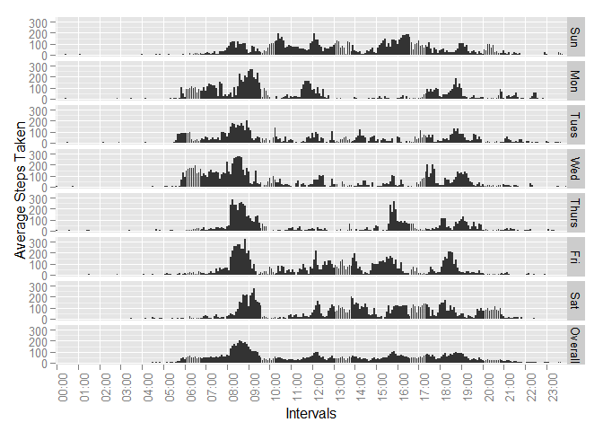

```r
# Calculate average steps by interval, overall
estimates_overall = dt[,
  .(nobs = sum(!is.na(steps)), average_steps = mean(steps, na.rm = TRUE)),
  interval
]
setkey(estimates_overall, interval)

# Calculate average steps by interval, by week day
estimates_dow = dt[,
  .(nobs = sum(!is.na(steps)), average_steps = mean(steps, na.rm = TRUE)),
  .(dow  = wday(date, label = TRUE, abbr = TRUE), interval)
]
setkey(estimates_dow, dow, interval)

# Review if these methods yield very different extimates
comb = rbind(
  estimates_overall[, dow := "Overall"],
  estimates_dow
)

# See a comparison of these estimates
ggplot(comb, aes(x = interval, y = average_steps)) +
  facet_grid       ( dow ~ .) +
  geom_bar         ( stat = "identity") +
  xlab             ( "Intervals") +
  ylab             ( "Average Steps Taken") +
  scale_x_discrete ( breaks = labels, labels = as.character(labels)) +
  theme            ( axis.text.x = element_text(angle = 90))
```

It is clear from these plots that applying day-of-week-specific averages will give us better estimates to impute the missing data points.

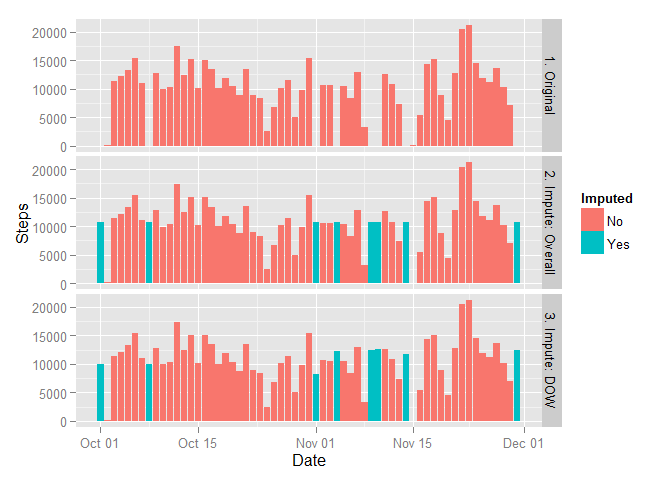

```r
# To compare the alternative estimation methods, create two imputed variables
dt[is.na(steps),
  `:=`(
    imputed_flag = TRUE,
    imputed_dow = estimates_dow[
      .SD[, .(dow = wday(date, label = TRUE, abbr = TRUE), interval)],
      average_steps
    ],
    imputed_overall = estimates_overall[
      .SD[, interval],
      average_steps
    ]
  )
]
dt[!is.na(steps),
  `:=`(
    imputed_flag    = FALSE,
    imputed_dow = steps,
    imputed_overall = steps
  )
]

# No need to summarize, ggplot aggregates correctly
stacked = rbind(
  dt[, .(date, interval, Method = "1. Original", Imputed = "No", steps)],
  dt[is.na(steps),
    .(
      date,
      interval,
      Method  = "2. Impute: Overall",
      Imputed = "Yes",
      steps   = estimates_overall[.SD[, interval], average_steps]
    )
  ],
  dt[!is.na(steps), .(date, interval, Method = "2. Impute: Overall", Imputed = "No", steps)],
  dt[is.na(steps),
    .(
      date,
      interval,
      Method  = "3. Impute: DOW",
      Imputed = "Yes",
      steps   = estimates_dow[
        .SD[, .(dow = wday(date, label = TRUE, abbr = TRUE), interval)],
        average_steps
      ]
    )
  ],
  dt[!is.na(steps), .(date, interval, Method = "3. Impute: DOW", Imputed = "No", steps)]
)

# Plot this, show both the original and the imputed variables
ggplot(stacked, aes(x = date, y = steps, fill = Imputed) ) +
  geom_bar   ( stat = "identity" ) +
  facet_grid ( Method ~ . ) +
  xlab       ( "Date" ) +
  ylab       ( "Steps" )
```

Now, let’s review if the distribution from part 2 was affected because we have imputed values for the missing data.

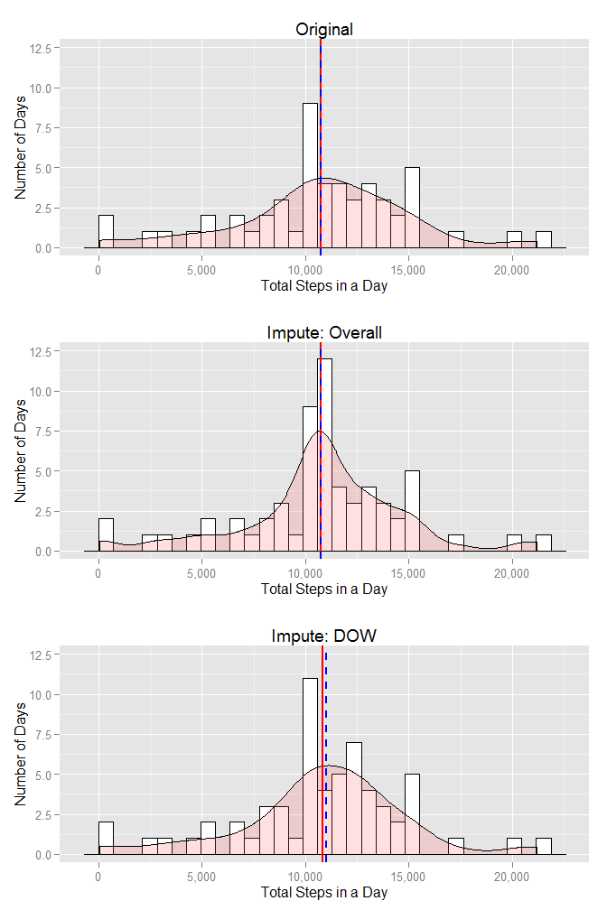

```r
# Compare histograms after imputing steps
step_by_date_impute = na.omit(stacked[,
  .(total_steps = sum(steps)),
  .(date, Method)
])

# Since we are not using facets, manually force the same y-axis scale
plot_it3 = function(dt_to_plot, scale, plot_title) {
  ggplot(dt_to_plot, aes(x = total_steps)) +
    geom_histogram     ( colour = "black", fill = "white"                     ) +
    ggtitle            ( plot_title                                           ) +
    xlab               ( "Total Steps in a Day"                               ) +
    ylab               ( "Number of Days"                                     ) +
    scale_x_continuous ( labels = comma                                       ) +
    geom_density       ( aes_string(y = scale), alpha = 0.2, fill = "#FF6666" ) +
    geom_vline         ( aes(xintercept = mean(total_steps, na.rm = TRUE)),
                         color = "red", size = 1                              ) +
    geom_vline         ( aes(xintercept = median(total_steps, na.rm = TRUE)),
                         color = "blue", linetype = "dashed", size = 1        ) +
    coord_cartesian    ( ylim = c(-0.5, 13)                                   )
}

hist1 = plot_it3(step_by_date_impute[Method == "1. Original"]       , "..scaled..*4.35", "Original")
hist2 = plot_it3(step_by_date_impute[Method == "2. Impute: Overall"], "..scaled..*7.50", "Impute: Overall")
hist3 = plot_it3(step_by_date_impute[Method == "3. Impute: DOW"]    , "..scaled..*5.55", "Impute: DOW")

# Arrange plots in a grid easily
require(gridExtra)
grid.arrange(hist1, hist2, hist3)
```

```r
# mean steps taken - comparison
step_by_date_impute[,
  .(.N, mean = mean(total_steps), median = median(total_steps)),
  Method
]
```

```
##                Method  N     mean   median
## 1:        1. Original 53 10766.19 10765.00
## 2: 2. Impute: Overall 61 10766.19 10766.19
## 3:     3. Impute: DOW 61 10821.21 11015.00
```

As we can see from the above results, the mean total steps per day didn’t change for *Impute: Overall* method. The median is slightly higher now, and it is the same as the mean. However, the shape of distribution has changed visible, and there is now another tall bar around the mean. For *Impute: DOW (Day of Week)* method, both the mean and the median are higher after the missing data were replaced with imputed values. However, the distribution of total steps per day is not much different from the original plot.

## Are there differences in activity patterns between weekdays and weekends?

In the previous section, we have visually observed that the pattern of daily activity was different on different days of the week. To answer the specific question about the activity patterns during week days and weekend, we will summarize the activities of the week days as one group and the activities of the weekends as a second group and plot them.

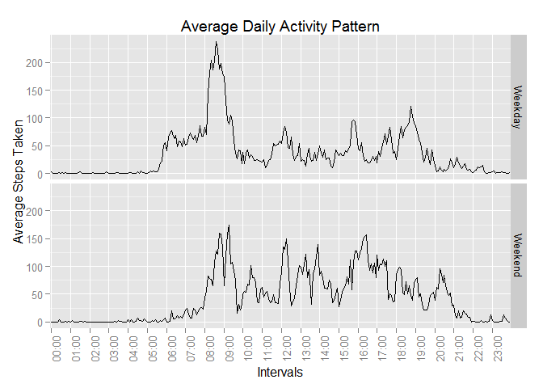

```r
# Add a variable to identify week days and weekend days
dt[, Type := ifelse(wday(date) %in% 2:6, "Weekday", "Weekend")]

# Daily activity pattern, summarized separtely for week days and weekends
weekday_weekend = dt[,
  .(average_steps = mean(imputed_dow)),
  .(interval, Type)
]

# Line graph of average activity during the day: Week day vs Weekend
# Note: x-axis labels were created in part 2 above
ggplot(weekday_weekend, aes(x = interval, y = average_steps, group = Type)) +
  geom_line          (                                                ) +
  facet_grid         ( Type ~ .                                       ) +
  ggtitle            ( "Average Daily Activity Pattern"               ) +
  xlab               ( "Intervals"                                    ) +
  ylab               ( "Average Steps Taken"                          ) +
  scale_x_discrete   ( breaks = labels, labels = as.character(labels) ) +
  scale_y_continuous ( labels = comma                                 ) +
  theme              ( axis.text.x = element_text(angle = 90)         )
```

These two plots clearly show that the activity patterns between week days and weekends are different.